# HAI and Antimicrobial Use Point Prevalence Survey

Data quality and survey report (synthetic data)

09 November 2026

**All data in this report is synthetic.** It was generated from scratch in the layout of a REDCap export for an HAI and antimicrobial use point prevalence survey: 540 patients in 10 invented hospitals, with data errors planted deliberately to demonstrate the quality checks. No real patient, facility or programme data was used. The HAI classification uses simplified definitions for demonstration (see the definitions on each page).

## 1. Data quality

**543**records exported (562 fields)

**122**validation rules applied

**67**queries raised on 67 records

**27**critical queries

**516**records included in analysis (95.0%)

Records with an open **critical** query (impossible value, unidentifiable or duplicated patient) are held back from the survey analysis on the following pages until the hospital resolves them. Records with major or minor queries stay in, flagged.

### 1.1 Patient age, with outliers labelled by record ID

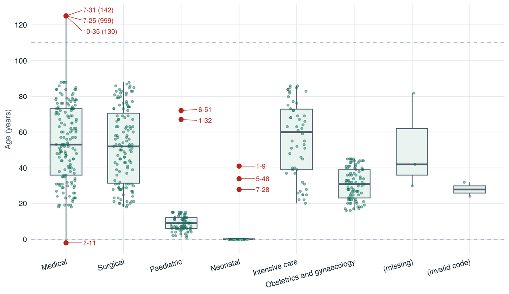

Red points are flagged, labelled with the record ID; values beyond the plotted range are shown at the edge with the actual value in brackets. Dashed lines mark the plausible range of 0 to 110 years.

| Record ID | Hospital | Ward | Age (years) | Reason |
| --- | --- | --- | --- | --- |
| 6-51 | hospital_06 | Paediatric | 72 | Implausible for ward |
| 1-32 | hospital_01 | Paediatric | 67 | Implausible for ward |
| 5-48 | hospital_05 | Neonatal | 34 | Implausible for ward |
| 1-9 | hospital_01 | Neonatal | 41 | Implausible for ward |
| 7-28 | hospital_07 | Neonatal | 28 | Implausible for ward |
| 10-35 | hospital_10 | Medical | 130 | Impossible (outside 0 to 110) |
| 7-31 | hospital_07 | Medical | 142 | Impossible (outside 0 to 110) |
| 7-25 | hospital_07 | Medical | 999 | Impossible (outside 0 to 110) |
| 2-11 | hospital_02 | Medical | -2 | Impossible (outside 0 to 110) |

### 1.2 Length of stay, with outliers labelled by record ID

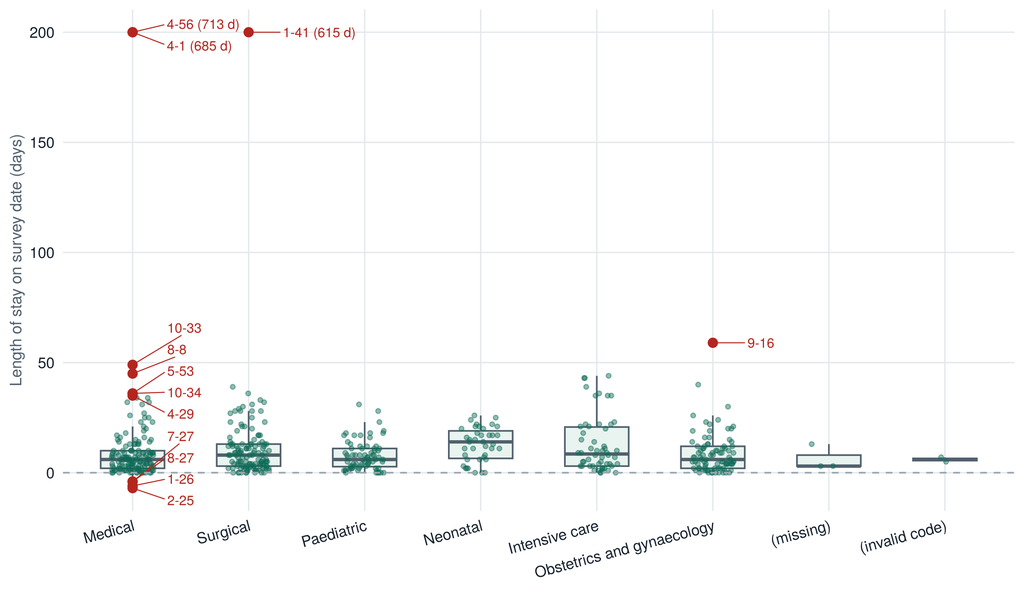

Length of stay is the survey date minus the admission date. Statistical outliers on the long side are not errors in themselves; they are listed so the hospital can confirm the admission date.

| Record ID | Hospital | Ward | Length of stay (days) | Reason |
| --- | --- | --- | --- | --- |
| 9-16 | hospital_09 | Obstetrics and gynaecology | 59 | Extreme for ward (above Q3 + 3 x IQR) |
| 10-33 | hospital_10 | Medical | 49 | Extreme for ward (above Q3 + 3 x IQR) |
| 8-8 | hospital_08 | Medical | 45 | Extreme for ward (above Q3 + 3 x IQR) |
| 5-53 | hospital_05 | Medical | 36 | Extreme for ward (above Q3 + 3 x IQR) |
| 10-34 | hospital_10 | Medical | 36 | Extreme for ward (above Q3 + 3 x IQR) |
| 4-29 | hospital_04 | Medical | 35 | Extreme for ward (above Q3 + 3 x IQR) |
| 4-56 | hospital_04 | Medical | 713 | Longer than 365 days |
| 4-1 | hospital_04 | Medical | 685 | Longer than 365 days |
| 1-41 | hospital_01 | Surgical | 615 | Longer than 365 days |
| 7-27 | hospital_07 | Medical | -4 | Negative (admitted after survey date) |
| 8-27 | hospital_08 | Medical | -4 | Negative (admitted after survey date) |
| 1-26 | hospital_01 | Medical | -6 | Negative (admitted after survey date) |
| 2-25 | hospital_02 | Medical | -7 | Negative (admitted after survey date) |

### 1.3 Patients on the same ward with different survey dates

Each ward should be surveyed on a single day. The table lists wards where some patients carry a different survey date from the rest of the ward.

| Hospital | Ward | Ward survey date | Patients on ward | Patients on another date | Other dates (record IDs) |
| --- | --- | --- | --- | --- | --- |
| hospital_02 | Medical | 2025-03-04 | 21 | 2 | 2025-03-02 (2-36); 2025-03-06 (2-50) |
| hospital_04 | Medical | 2025-03-10 | 20 | 1 | 2025-03-12 (4-11) |
| hospital_06 | Medical | 2025-03-18 | 14 | 1 | 2025-03-20 (6-39) |
| hospital_08 | Medical | 2025-03-26 | 13 | 3 | 2025-03-28 (8-31); 2025-03-30 (8-22); 2025-03-30 (8-42) |
| hospital_10 | Medical | 2025-04-02 | 17 | 2 | 2025-03-31 (10-4); 2025-04-06 (10-40) |

### 1.4 Other quality issues

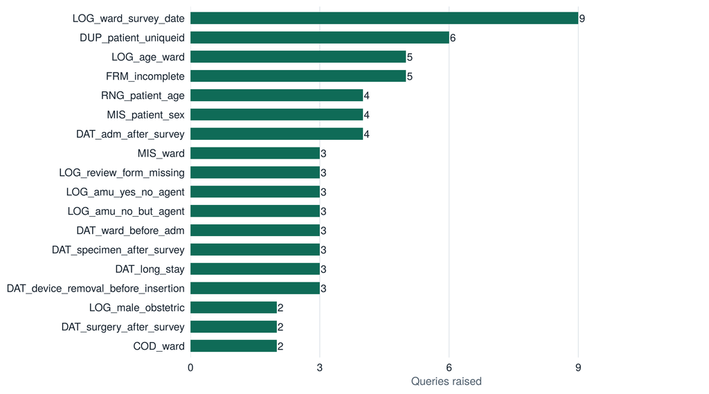

| Rule | Severity | Check | Queries |
| --- | --- | --- | --- |
| LOG_ward_survey_date | Major | Survey date differs from the date the rest of the ward was surveyed | 9 |
| DUP_patient_uniqueid | Critical | Same patient ID entered under more than one record | 6 |
| FRM_incomplete | Minor | Survey submission not marked complete | 5 |
| LOG_age_ward | Major | Age is implausible for the ward (neonatal ward aged 1+, paediatric ward aged 18+) | 5 |
| DAT_adm_after_survey | Critical | Admission date is after the survey date (negative length of stay) | 4 |
| MIS_patient_sex | Major | patient_sex is missing | 4 |
| RNG_patient_age | Critical | patient_age is outside 0 to 110 | 4 |
| DAT_device_removal_before_insertion | Critical | A device removal date is before its insertion date | 3 |
| DAT_long_stay | Minor | Length of stay over 365 days | 3 |
| DAT_specimen_after_survey | Critical | A specimen was collected after the survey date | 3 |
| DAT_ward_before_adm | Major | Ward admission date is before hospital admission date | 3 |
| LOG_amu_no_but_agent | Major | Not on antimicrobials, but an agent is recorded | 3 |
| LOG_amu_yes_no_agent | Major | On antimicrobials, but no agent recorded | 3 |
| LOG_review_form_missing | Major | Patient meets HAI review criteria and a review trigger, but the classification form is blank | 3 |
| MIS_ward | Critical | ward is missing | 3 |
| COD_ward | Critical | ward is not one of the allowed codes | 2 |
| DAT_surgery_after_survey | Critical | A procedure date is after the survey date | 2 |
| LOG_male_obstetric | Major | Male patient on an obstetrics and gynaecology ward | 2 |

**Severity.** *Critical:* impossible or unidentifiable, so the record is held back. *Major:* missing or inconsistent, so it would bias an estimate. *Minor:* unusual but possible, so it only needs confirmation.

Queries by hospital

| Hospital | Records | Queries | Critical | Queries per 100 records |
| --- | --- | --- | --- | --- |
| hospital_10 | 40 | 10 | 4 | 25.0 |
| hospital_08 | 44 | 7 | 3 | 15.9 |
| hospital_01 | 72 | 9 | 3 | 12.5 |
| hospital_02 | 66 | 8 | 3 | 12.1 |
| hospital_07 | 50 | 6 | 4 | 12.0 |
| hospital_09 | 44 | 5 | 5 | 11.4 |
| hospital_06 | 53 | 6 | 2 | 11.3 |
| hospital_03 | 62 | 7 | 2 | 11.3 |
| hospital_04 | 58 | 6 | 1 | 10.3 |
| hospital_05 | 54 | 3 | 0 | 5.6 |

Data collectors with the highest query rates

| Data collector | Queries | Records | Queries per 100 records |
| --- | --- | --- | --- |
| dc19 | 7 | 20 | 35.0 |
| dc15 | 5 | 23 | 21.7 |
| dc01 | 5 | 29 | 17.2 |
| dc13 | 3 | 20 | 15.0 |
| dc20 | 3 | 20 | 15.0 |
| dc18 | 3 | 21 | 14.3 |

The full query log, with a plain-language request to the hospital for every issue, is in `outputs/query_log.csv`, and one file per hospital in `outputs/query_logs_by_site/`.

Query log: first 12 queries by severity

| Query | Hospital | Record | Severity | Rule | Current value | Request to hospital |
| --- | --- | --- | --- | --- | --- | --- |
| Q0002 | hospital_01 | 1-17 | Critical | COD_ward | ward = 8 | ward has a value outside the allowed list (1, 2, 3, 4, 5, 6). Please correct it. |
| Q0003 | hospital_01 | 1-26 | Critical | DAT_adm_after_survey | admission_date = 2025-03-11; survey_date = 2025-03-05 | Admission date is after the survey date. Please verify both dates. |
| Q0006 | hospital_01 | 1-49 | Critical | DAT_device_removal_before_insertion | urinary_insertion1 = 2025-02-03; urinary_removal1 = 2025-01-31 | A device removal date is before its insertion date. Please verify both dates. |
| Q0010 | hospital_02 | 2-11 | Critical | RNG_patient_age | patient_age = -2 | patient_age is outside the plausible range of 0 to 110. Please verify it. |
| Q0011 | hospital_02 | 2-25 | Critical | DAT_adm_after_survey | admission_date = 2025-03-11; survey_date = 2025-03-04 | Admission date is after the survey date. Please verify both dates. |
| Q0013 | hospital_02 | 2-42 | Critical | DAT_device_removal_before_insertion | urinary_insertion1 = 2025-02-23; urinary_removal1 = 2025-02-19 | A device removal date is before its insertion date. Please verify both dates. |
| Q0019 | hospital_03 | 3-32 | Critical | DAT_specimen_after_survey | specimen_collection_date = 2025-03-13; survey_date = 2025-03-11 | A specimen collection date is after the survey date. Please verify it. |
| Q0020 | hospital_03 | 3-46 | Critical | DAT_specimen_after_survey | specimen_collection_date = 2025-03-18; survey_date = 2025-03-12 | A specimen collection date is after the survey date. Please verify it. |
| Q0028 | hospital_04 | 4-29 | Critical | DAT_specimen_after_survey | specimen_collection_date = 2025-03-13; survey_date = 2025-03-10 | A specimen collection date is after the survey date. Please verify it. |
| Q0036 | hospital_06 | 6-41 | Critical | DUP_patient_uniqueid | patient_uniqueid = PPS-H06-0041 | This patient ID appears under more than one record ID. Please confirm whether the patient was entered twice and which record to keep. |
| Q0039 | hospital_06 | 6-901 | Critical | DUP_patient_uniqueid | patient_uniqueid = PPS-H06-0041 | This patient ID appears under more than one record ID. Please confirm whether the patient was entered twice and which record to keep. |
| Q0040 | hospital_07 | 7-22 | Critical | DAT_surgery_after_survey | prior_surgery_1 = 2025-03-31; survey_date = 2025-03-24 | A procedure date is after the survey date. Please verify it. |

## 2. General survey report

**HAI chart review criteria** (set in `R/03_derive_indicators.R`): **Non-surgical:** receiving antimicrobials on the survey date **and** on hospital day 3 or later. **Surgical:** an operative procedure in the 30 days before the survey date. A patient meeting either set of criteria undergoes HAI chart review.

**516**patients surveyed

**340 (65.9%)**on antimicrobials

**286 (55.4%)**2.1 met non-surgical criteria

**130 (25.2%)**2.2 met surgical criteria

**331 (64.1%)**2.3 total for HAI chart review

| Review group | Patients | % of surveyed |
| --- | --- | --- |
| Non-surgical criteria only | 201 | 39.0% |
| Surgical criteria only | 45 | 8.7% |
| Both criteria | 85 | 16.5% |
| Total for HAI chart review | 331 | 64.1% |
| Not eligible for review | 185 | 35.9% |

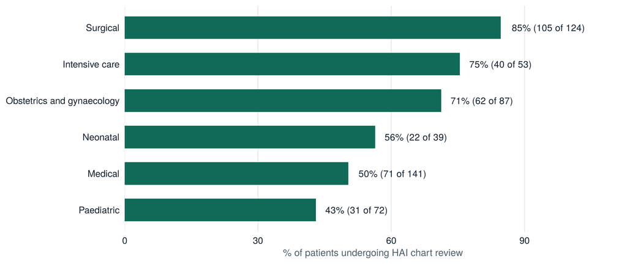

By ward

| Ward | Patients | 2.1 Non-surgical | 2.2 Surgical | 2.3 Total for review | % reviewed |
| --- | --- | --- | --- | --- | --- |
| Medical | 141 | 67 | 7 | 71 | 50.4% |
| Surgical | 124 | 83 | 72 | 105 | 84.7% |
| Paediatric | 72 | 31 | 1 | 31 | 43.1% |
| Neonatal | 39 | 21 | 1 | 22 | 56.4% |
| Intensive care | 53 | 38 | 7 | 40 | 75.5% |
| Obstetrics and gynaecology | 87 | 46 | 42 | 62 | 71.3% |

By hospital

| Hospital | Patients | 2.1 Non-surgical | 2.2 Surgical | 2.3 Total for review | % reviewed |
| --- | --- | --- | --- | --- | --- |
| Hospital 01 | 69 | 41 | 14 | 44 | 63.8% |
| Hospital 02 | 63 | 39 | 14 | 43 | 68.3% |
| Hospital 03 | 60 | 32 | 17 | 36 | 60.0% |
| Hospital 04 | 57 | 26 | 11 | 29 | 50.9% |
| Hospital 05 | 54 | 32 | 14 | 38 | 70.4% |
| Hospital 06 | 51 | 28 | 16 | 33 | 64.7% |
| Hospital 07 | 46 | 21 | 12 | 28 | 60.9% |
| Hospital 08 | 41 | 25 | 12 | 27 | 65.9% |
| Hospital 09 | 39 | 21 | 13 | 27 | 69.2% |
| Hospital 10 | 36 | 21 | 7 | 26 | 72.2% |

## 3. Microbiology

Culture results for all included patients, from specimens recorded in the survey. Positivity is shown per culture and per patient tested.

### 3.1 Blood cultures

| Measure | Value |
| --- | --- |
| Cultures performed | 89 |
| Patients tested | 84 |
| Positive cultures | 33 |
| Culture positivity | 37.1% |
| Patients with a positive culture | 33 |
| Patient positivity | 39.3% |

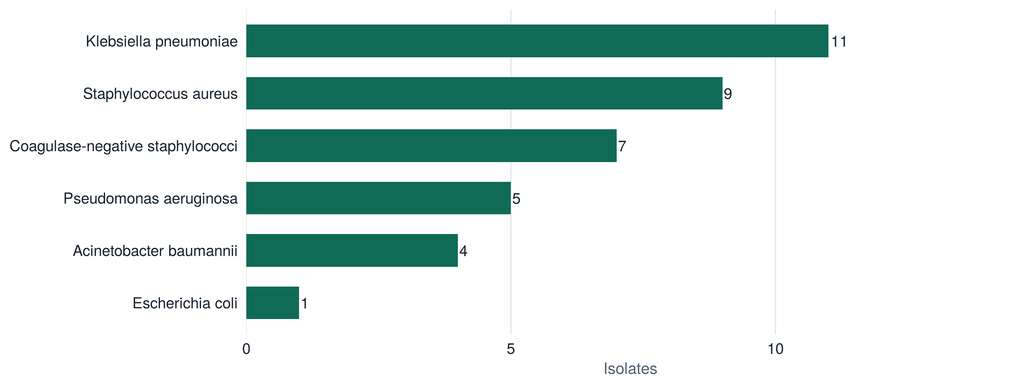

Organisms from blood cultures

| Organism | Isolates | % of isolates |
| --- | --- | --- |
| Klebsiella pneumoniae | 11 | 29.7% |
| Staphylococcus aureus | 9 | 24.3% |
| Coagulase-negative staphylococci | 7 | 18.9% |
| Pseudomonas aeruginosa | 5 | 13.5% |
| Acinetobacter baumannii | 4 | 10.8% |
| Escherichia coli | 1 | 2.7% |

A single isolate of coagulase-negative staphylococci is usually a contaminant. It is counted here as a positive culture, but it does not meet the BSI definition on page 7.

### 3.2 Urine cultures

| Measure | Value |
| --- | --- |
| Cultures performed | 92 |
| Patients tested | 90 |
| Positive cultures | 32 |
| Culture positivity | 34.8% |
| Patients with a positive culture | 32 |
| Patient positivity | 35.6% |

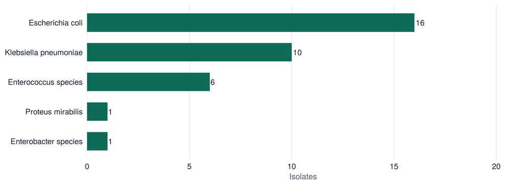

Organisms from urine cultures

| Organism | Isolates | % of isolates |
| --- | --- | --- |
| Escherichia coli | 16 | 47.1% |
| Klebsiella pneumoniae | 10 | 29.4% |
| Enterococcus species | 6 | 17.6% |
| Enterobacter species | 1 | 2.9% |
| Proteus mirabilis | 1 | 2.9% |

### 3.3 Respiratory cultures

| Measure | Value |
| --- | --- |
| Cultures performed | 35 |
| Patients tested | 35 |
| Positive cultures | 10 |
| Culture positivity | 28.6% |
| Patients with a positive culture | 10 |
| Patient positivity | 28.6% |

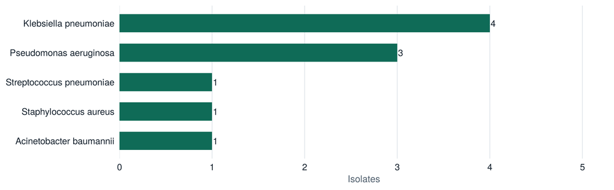

Organisms from respiratory cultures

| Organism | Isolates | % of isolates |
| --- | --- | --- |
| Klebsiella pneumoniae | 4 | 40.0% |
| Pseudomonas aeruginosa | 3 | 30.0% |
| Acinetobacter baumannii | 1 | 10.0% |
| Staphylococcus aureus | 1 | 10.0% |
| Streptococcus pneumoniae | 1 | 10.0% |

## 4. Devices

### 4.1 Devices present on the survey date among patients on antimicrobials

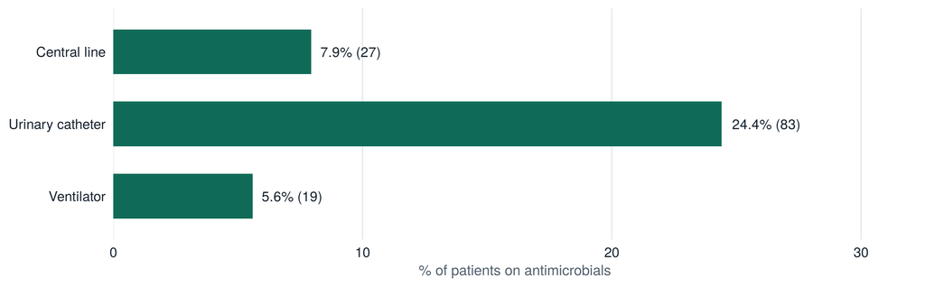

Denominator: 340 patients on antimicrobials

| Device | Patients | % of patients on antimicrobials |
| --- | --- | --- |
| Central line | 27 | 7.9% |
| Urinary catheter | 83 | 24.4% |
| Ventilator | 19 | 5.6% |
| Any device | 105 | 30.9% |

### 4.2 Devices present in the 14 days before the survey date

A device counts if it was in place on any day from 14 days before the survey date to the survey date

| Device | All patients | Patients on antimicrobials |
| --- | --- | --- |
| Central line | 44 (8.5%) | 33 (9.7%) |
| Urinary catheter | 137 (26.6%) | 99 (29.1%) |
| Ventilator | 26 (5.0%) | 24 (7.1%) |
| Any device | 165 (32.0%) | 123 (36.2%) |

### 4.3 Mean device duration

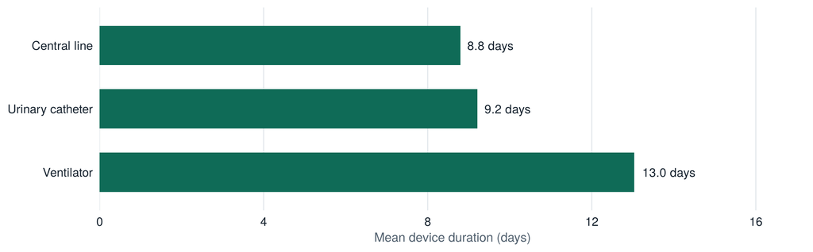

| Device | Episodes | Mean (days) | SD | Median (IQR) | Range |
| --- | --- | --- | --- | --- | --- |
| Central line | 49 | 8.8 | 8.9 | 5 (3 to 12) | 1 to 44 |
| Urinary catheter | 140 | 9.2 | 9.1 | 6 (2 to 12) | 1 to 41 |
| Ventilator | 26 | 13.0 | 12.8 | 8 (3 to 20) | 1 to 40 |

Duration runs from the insertion date to the removal date, or to the survey date if the device was still in place, counting both days.

## 5. Antimicrobial and diagnostic metrics

Patients who underwent HAI chart review **and** were receiving antimicrobials on the survey date: **297**.

**550**antimicrobials prescribed

**1.85**antimicrobials per patient

**56.6%**patients on 2 or more

**78.9%**prescriptions parenteral

Most prescribed antimicrobials

| Agent | Prescriptions | % of prescriptions |
| --- | --- | --- |
| Ceftriaxone | 107 | 19.5% |
| Metronidazole | 91 | 16.5% |
| Amoxicillin-clavulanate | 67 | 12.2% |
| Ciprofloxacin | 61 | 11.1% |
| Gentamicin | 50 | 9.1% |
| Cefuroxime | 36 | 6.5% |
| Ampicillin | 35 | 6.4% |
| Ceftazidime | 33 | 6.0% |
| Meropenem | 25 | 4.5% |
| Azithromycin | 24 | 4.4% |

Indication

| Indication | Prescriptions | % of prescriptions |
| --- | --- | --- |
| Community-onset infection | 250 | 45.5% |
| Medical prophylaxis | 76 | 13.8% |
| Surgical prophylaxis | 75 | 13.6% |
| Hospital-onset infection | 69 | 12.5% |
| Unknown | 60 | 10.9% |
| Other | 20 | 3.6% |

### 5.1 Diagnostic test utilisation among patients on antimicrobials

A test counts if the specimen was collected, or imaging done, in the review window (the 14 days up to the survey date, or since admission if shorter).

| Measure | Patients | % of patients on antimicrobials |
| --- | --- | --- |
| Any diagnostic test (culture or chest imaging) | 183 | 61.6% |
| Any culture | 157 | 52.9% |
| No diagnostic test | 114 | 38.4% |

### 5.2 Utilisation by test type

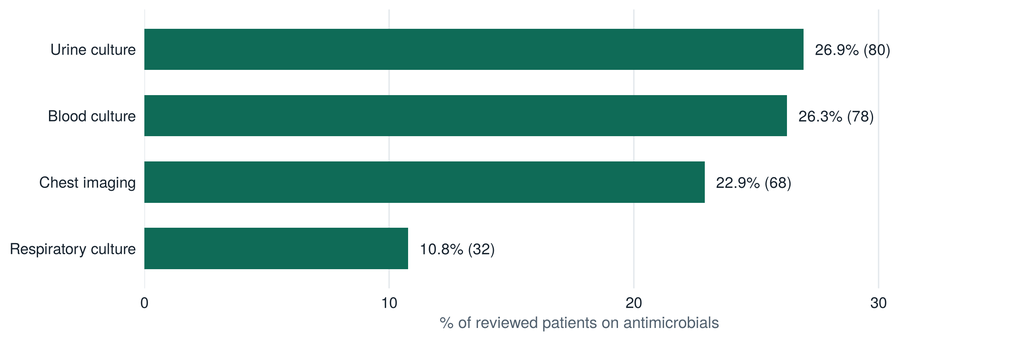

| Test | Patients | % of patients on antimicrobials |
| --- | --- | --- |
| Blood culture | 78 | 26.3% |
| Urine culture | 80 | 26.9% |
| Respiratory culture | 32 | 10.8% |
| Chest imaging | 68 | 22.9% |

Culture use by purpose of antimicrobial therapy

| Antimicrobial purpose | Patients | Any culture | Blood culture | Chest imaging |
| --- | --- | --- | --- | --- |
| Prophylaxis, other or unknown only | 77 | 48.1% | 23.4% | 16.9% |
| Treating an infection | 220 | 54.5% | 27.3% | 25.0% |

## 6. UTI

**Reviewed for UTI:** under HAI chart review (non-surgical criteria) with a urine culture, urinalysis, urinary catheter or clinician-documented UTI, so the UTI classification form was completed. **Meets the UTI definition (simplified):** positive urine culture (not *Candida* only) in the review window, at least one UTI sign or symptom not present on admission, and onset on hospital day 3 or later. **Catheter-associated (CAUTI):** urinary catheter in place for more than 2 days on the date of event.

| Measure | Patients | % of reviewed |
| --- | --- | --- |
| Patients reviewed | 139 | 100.0% |
| Met the HAI definition | 19 | 13.7% |
| Infection present on admission (not an HAI) | 6 | 4.3% |
| Did not meet the definition | 114 | 82.0% |

Signs and symptoms among patients meeting the UTI definition

| Sign or symptom | Patients | % of HAI cases |
| --- | --- | --- |
| Fever | 5 | 26.3% |
| Urgency | 6 | 31.6% |
| Frequency | 9 | 47.4% |
| Dysuria | 6 | 31.6% |
| Costovertebral tenderness | 2 | 10.5% |
| Suprapubic pain | 3 | 15.8% |
| Flank pain | 5 | 26.3% |

| Measure | Patients | % of UTI |
| --- | --- | --- |
| Catheter-associated UTI (CAUTI) | 10 | 52.6% |

Organisms causing UTI

| Organism | Isolates |
| --- | --- |
| Escherichia coli | 9 |
| Klebsiella pneumoniae | 5 |
| Enterococcus species | 4 |
| Enterobacter species | 1 |
| Proteus mirabilis | 1 |

By ward

| Ward | Surveyed | Reviewed | HAI | HAI per 100 surveyed |
| --- | --- | --- | --- | --- |
| Medical | 141 | 22 | 7 | 5.0 |
| Surgical | 124 | 40 | 2 | 1.6 |
| Paediatric | 72 | 9 | 2 | 2.8 |
| Neonatal | 39 | 9 | 4 | 10.3 |
| Intensive care | 53 | 30 | 3 | 5.7 |
| Obstetrics and gynaecology | 87 | 29 | 1 | 1.1 |

## 7. BSI

**Reviewed for BSI:** under HAI chart review (non-surgical criteria) with a blood culture in the review window, so the BSI classification form was completed. **Meets the BSI definition (simplified):** blood culture positive for a recognised pathogen in the review window (a single coagulase-negative staphylococcus is treated as a contaminant), not present on admission, onset on hospital day 3 or later. **Central line-associated (CLABSI):** central line in place for more than 2 days on the date of event.

| Measure | Patients | % of reviewed |
| --- | --- | --- |
| Patients reviewed | 72 | 100.0% |
| Met the HAI definition | 19 | 26.4% |
| Infection present on admission (not an HAI) | 7 | 9.7% |
| Did not meet the definition | 46 | 63.9% |

Signs among patients meeting the BSI definition

| Sign or symptom | Patients | % of HAI cases |
| --- | --- | --- |
| Fever | 8 | 42.1% |
| Chills | 9 | 47.4% |
| Hypotension | 14 | 73.7% |

| Measure | Patients | % of BSI |
| --- | --- | --- |
| Central line-associated BSI (CLABSI) | 9 | 47.4% |

Organisms causing BSI

| Organism | Isolates |
| --- | --- |
| Klebsiella pneumoniae | 10 |
| Staphylococcus aureus | 7 |
| Pseudomonas aeruginosa | 3 |
| Acinetobacter baumannii | 1 |
| Escherichia coli | 1 |

By ward

| Ward | Surveyed | Reviewed | HAI | HAI per 100 surveyed |
| --- | --- | --- | --- | --- |
| Medical | 141 | 20 | 4 | 2.8 |
| Surgical | 124 | 16 | 6 | 4.8 |
| Paediatric | 72 | 10 | 4 | 5.6 |
| Neonatal | 39 | 6 | 1 | 2.6 |
| Intensive care | 53 | 8 | 4 | 7.5 |
| Obstetrics and gynaecology | 87 | 12 | 0 | 0.0 |

## 8. Pneumonia

**Reviewed for pneumonia:** under HAI chart review (non-surgical criteria) with chest imaging, a respiratory culture or clinician-documented pneumonia, so the pneumonia classification form was completed. **Meets the pneumonia definition (simplified):** chest imaging consistent with pneumonia in the review window, fever plus at least one respiratory sign or symptom, not present on admission, onset on hospital day 3 or later. **Ventilator-associated (VAP):** ventilator in place for more than 2 days on the date of event.

| Measure | Patients | % of reviewed |
| --- | --- | --- |
| Patients reviewed | 82 | 100.0% |
| Met the HAI definition | 19 | 23.2% |
| Infection present on admission (not an HAI) | 12 | 14.6% |
| Did not meet the definition | 51 | 62.2% |

Signs and symptoms among patients meeting the pneumonia definition

| Sign or symptom | Patients | % of HAI cases |
| --- | --- | --- |
| Fever | 19 | 100.0% |
| Cough | 5 | 26.3% |
| New or changed sputum | 8 | 42.1% |
| Abnormal auscultation | 7 | 36.8% |
| Worsening gas exchange | 4 | 21.1% |
| Tachypnoea | 6 | 31.6% |
| Dyspnoea | 8 | 42.1% |

| Measure | Patients | % of pneumonia |
| --- | --- | --- |
| Ventilator-associated pneumonia (VAP) | 3 | 15.8% |

A respiratory culture was done for 9 (47.4%) of patients meeting the pneumonia definition.

Organisms from respiratory cultures in pneumonia cases

| Organism | Isolates |
| --- | --- |
| Klebsiella pneumoniae | 4 |
| Pseudomonas aeruginosa | 2 |
| Acinetobacter baumannii | 1 |
| Streptococcus pneumoniae | 1 |

By ward

| Ward | Surveyed | Reviewed | HAI | HAI per 100 surveyed |
| --- | --- | --- | --- | --- |
| Medical | 141 | 19 | 6 | 4.3 |
| Surgical | 124 | 28 | 6 | 4.8 |
| Paediatric | 72 | 7 | 2 | 2.8 |
| Neonatal | 39 | 5 | 0 | 0.0 |
| Intensive care | 53 | 7 | 3 | 5.7 |
| Obstetrics and gynaecology | 87 | 16 | 2 | 2.3 |

## 9. SSI

**Reviewed for SSI:** met the surgical criteria (an operative procedure in the 30 days before the survey date), so the SSI form was completed. **Meets the SSI definition (simplified):** SSI diagnosed within 30 days after the procedure, with purulent drainage, an abscess, or a deliberately opened incision with fever, pain or swelling.

| Measure | Patients | % of reviewed |
| --- | --- | --- |
| Patients reviewed | 130 | 100.0% |
| Met the HAI definition | 13 | 10.0% |
| Did not meet the definition | 117 | 90.0% |

Signs among patients meeting the SSI definition

| Sign | Patients | % of SSI cases |
| --- | --- | --- |
| Purulent drainage | 8 | 61.5% |
| Abscess | 3 | 23.1% |
| Incision deliberately opened | 2 | 15.4% |
| Fever | 5 | 38.5% |
| Localised pain | 6 | 46.2% |
| Swelling | 8 | 61.5% |

SSI depth

| Depth | Patients |
| --- | --- |
| Deep incisional | 4 |
| Superficial incisional | 9 |

Organisms from wound cultures in SSI cases

| Organism | Isolates |
| --- | --- |
| Pseudomonas aeruginosa | 2 |
| Enterobacter species | 1 |
| Escherichia coli | 1 |
| Staphylococcus aureus | 1 |

By ward

| Ward | Surveyed | Reviewed | HAI | HAI per 100 surveyed |
| --- | --- | --- | --- | --- |
| Medical | 141 | 7 | 0 | 0.0 |
| Surgical | 124 | 72 | 8 | 6.5 |
| Paediatric | 72 | 1 | 0 | 0.0 |
| Neonatal | 39 | 1 | 0 | 0.0 |
| Intensive care | 53 | 7 | 0 | 0.0 |
| Obstetrics and gynaecology | 87 | 42 | 5 | 5.7 |

## 10. HAI summary

**70**patients with at least one HAI

**13.6%**HAI prevalence among all surveyed (95% CI 10.9 to 16.8)

**21.1%**among patients reviewed (95% CI 17.1 to 25.9)

**70**HAI events

**22**device-associated HAIs

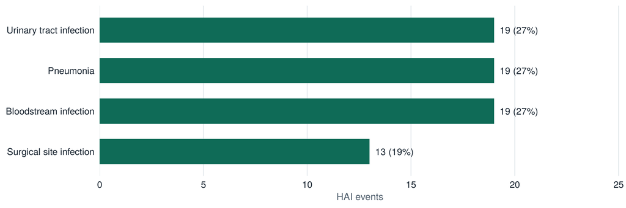

| HAI type | Events | % of HAI events | Prevalence per 100 surveyed | Device-associated |
| --- | --- | --- | --- | --- |
| Urinary tract infection | 19 | 27.1% | 3.7 | 10 |
| Bloodstream infection | 19 | 27.1% | 3.7 | 9 |
| Pneumonia | 19 | 27.1% | 3.7 | 3 |
| Surgical site infection | 13 | 18.6% | 2.5 | Not applicable |

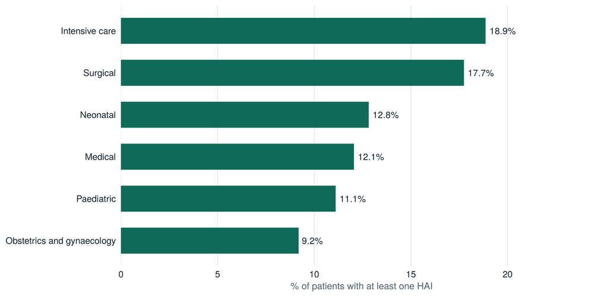

By ward

| Ward | Surveyed | With HAI | UTI | BSI | Pneumonia | SSI | HAI prevalence |
| --- | --- | --- | --- | --- | --- | --- | --- |
| Medical | 141 | 17 | 7 | 4 | 6 | 0 | 12.1% |
| Surgical | 124 | 22 | 2 | 6 | 6 | 8 | 17.7% |
| Paediatric | 72 | 8 | 2 | 4 | 2 | 0 | 11.1% |
| Neonatal | 39 | 5 | 4 | 1 | 0 | 0 | 12.8% |
| Intensive care | 53 | 10 | 3 | 4 | 3 | 0 | 18.9% |
| Obstetrics and gynaecology | 87 | 8 | 1 | 0 | 2 | 5 | 9.2% |

By hospital

| Hospital | Surveyed | With HAI | HAI prevalence (95% CI) |
| --- | --- | --- | --- |
| Hospital 01 | 69 | 15 | 21.7% (13.6 to 32.8) |
| Hospital 02 | 63 | 11 | 17.5% (10.0 to 28.6) |
| Hospital 03 | 60 | 4 | 6.7% (2.6 to 15.9) |
| Hospital 04 | 57 | 8 | 14.0% (7.3 to 25.3) |
| Hospital 05 | 54 | 5 | 9.3% (4.0 to 19.9) |
| Hospital 06 | 51 | 10 | 19.6% (11.0 to 32.5) |
| Hospital 07 | 46 | 4 | 8.7% (3.4 to 20.3) |
| Hospital 08 | 41 | 5 | 12.2% (5.3 to 25.5) |
| Hospital 09 | 39 | 4 | 10.3% (4.1 to 23.6) |
| Hospital 10 | 36 | 4 | 11.1% (4.4 to 25.3) |

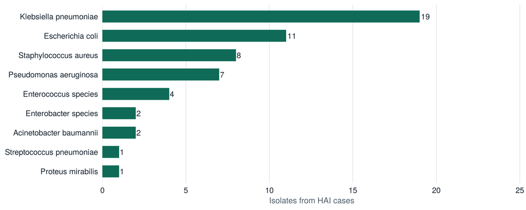

How many surveillance-defined HAIs the clinical team had documented

| HAI type | Met definition | Documented by clinician | % documented |
| --- | --- | --- | --- |
| UTI | 19 | 16 | 84.2% |
| BSI | 19 | 14 | 73.7% |
| Pneumonia | 19 | 13 | 68.4% |
| SSI | 13 | 9 | 69.2% |

Infections that meet the surveillance definition but are not documented by the clinical team point to under-recognition, and are a useful prompt for feedback to the ward.